# EEE 465 - Mini Project 4 - Nicolas Romano - November 19, 2021

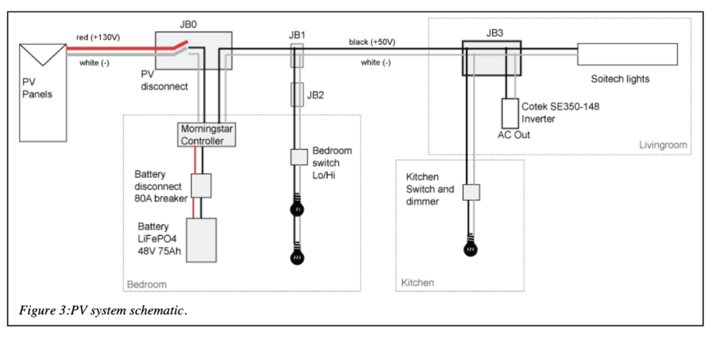

```python
from IPython.display import Image
Image(filename='System_Schematic.png')
```

System Description:

The goal of this project is to model an off-grid PV system located in Monument Valley, Arizona. The system consists of two fixed pole-mounted PV modules tilted at 30 degrees from horizontal and facing south. The other components are a Lithium Ion Battery (SimpliPhi 48V, 72Ah); 3 LED lights rated at 48V (4 W each), and 1 Solitech light that uses (24 W); a charge controller (MorningStar MPPT60); and a small inverter (95% efficient). For simplicity, it is assumed that the inverter efficiency is constant regardless of load size

Load Usage Patterns:

- All 4 lights go on 2 hours before sunset and turn off at 10pm
- The inverter load consists of a television screen (20 W) and laptop (30 W) (3 hrs per day); A chest freezer which operates 25% of the day (1 hour on, 3 hours off) controlled via a thermostat (95 W when on).

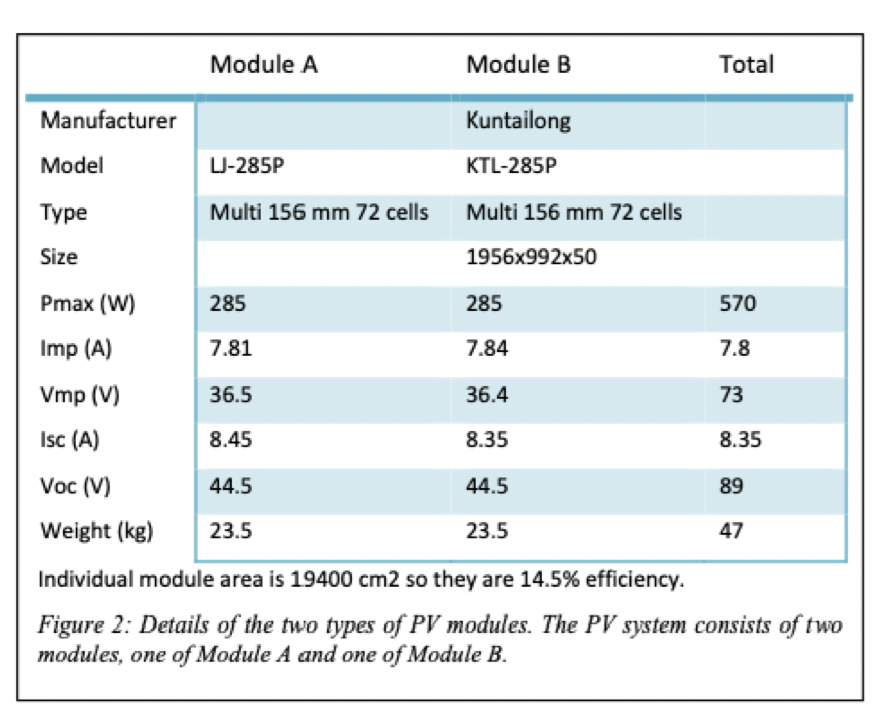

```python
Image(filename='SolarModuleInfo.png')
```

## Part 1: Calculation of PV System Hourly Parameters

1. Calculate and plot (1) the energy (Wh) and (2) Ah from the PV modules for every hour of the year including the effect of tilt angle. In the caption or graph also identify the location, the tilt of the modules, and the nominal or nameplate rating of the modules (which is 2 modules at 285W each or 0.57 kW) and the total kWh generated in the year.

```python
# Importing Packages:
import matplotlib.pyplot as plt
import numpy as np
import photovoltaic as pv
from photovoltaic.core import arccosd, arcsind, cosd, sind
import pandas as pd

# Constants:
module_azimuth = 180    # Facing South
module_elevation = 30   # Module Tilt from horizontal in degrees
module_area = 19400     # Module A & B Area in cm^2
P_max = 285             # Rated Power in [W]
PV_Module_Impp = 7.8    # Maximum Power Point current [A]
system_voltage = 48     # Nominal System Voltage
efficiency = 0.145

# Retrieving the Header information from the TMY Dataset using a Pandas dataframe:
# Page, Arizona:
df = pd.read_csv('NREL_PageAZ.CSV')

# These variables can be pulled from the column headers:
station, location_name, location_state, GMT_offset, latitude, longitude, altitude = df.columns[0:7]

# Converting string variables to floats/ints:
GMT_offset = int(float(GMT_offset))
latitude = float(latitude)
longitude = float(longitude)
altitude = float(altitude)

# Now that the location information is saved, we can create a new dataframe without the header row:
df = pd.read_csv('NREL_PageAZ.CSV', skiprows=1)
df['hour of day'] = df['Time (HH:MM)'].apply(lambda t: int(t[0:2]))    # create hour of day column

# Calculate the elevation and azimuth of the sun for every hour of the year in Page, AZ
df['elevations'], df['azimuths'] = pv.sun.sun_position((np.floor(df.index/24) + 1), latitude, longitude, GMT_offset,
                                                        df['hour of day'], 0)
# Compare the sun position to the module angle to calculate the fraction of direct irradiance
df['fraction_normal_to_module'] = pv.sun.module_direct(df['azimuths'], df['elevations'],
                                                        module_azimuth, module_elevation)
# Zero out fractions where the elevation is negative (night time):
df['fraction_normal_to_module'] = df.apply(lambda f: 0 if f['elevations'] < 0
                                           else f['fraction_normal_to_module'], axis = 1)
# calculate the direct normal irradiance on the module:
df['DNI_module'] = df['DNI (W/m^2)'] * df['fraction_normal_to_module']
# diffuse horizontal irradiance calculation:
df['diffuse_module'] = df['DHI (W/m^2)'] * (180 - module_elevation) / 180
# Total module irradiance in W/m^2
df['total_module'] = df['diffuse_module'] + df['DNI_module']

df['PV_Array_Ah'] = df['total_module']*PV_Module_Impp/1000
P_yearly = P_max*df['total_module'].sum()/1e3

df.head(24)
```

|  | Date (MM/DD/YYYY) | Time (HH:MM) | ETR (W/m^2) | ETRN (W/m^2) | GHI (W/m^2) | GHI source | GHI uncert (%) | DNI (W/m^2) | DNI source | DNI uncert (%) | ... | PresWth source | PresWth uncert (code) | hour of day | elevations | azimuths | fraction_normal_to_module | DNI_module | diffuse_module | total_module | PV_Array_Ah |
| --- | --- | --- | --- | --- | --- | --- | --- | --- | --- | --- | --- | --- | --- | --- | --- | --- | --- | --- | --- | --- | --- |
| 0 | 01/01/1999 | 01:00 | 0 | 0 | 0 | 2 | 0 | 0 | 2 | 0 | ... | C | 8 | 1 | -74.606066 | 27.387291 | 0.000000 | 0.000000 | 0.000000 | 0.000000 | 0.000000 |
| 1 | 01/01/1999 | 02:00 | 0 | 0 | 0 | 2 | 0 | 0 | 2 | 0 | ... | C | 8 | 2 | -66.065964 | 60.781389 | 0.000000 | 0.000000 | 0.000000 | 0.000000 | 0.000000 |
| 2 | 01/01/1999 | 03:00 | 0 | 0 | 0 | 2 | 0 | 0 | 2 | 0 | ... | C | 8 | 3 | -54.847447 | 77.402484 | 0.000000 | 0.000000 | 0.000000 | 0.000000 | 0.000000 |
| 3 | 01/01/1999 | 04:00 | 0 | 0 | 0 | 2 | 0 | 0 | 2 | 0 | ... | C | 8 | 4 | -42.962453 | 88.178481 | 0.000000 | 0.000000 | 0.000000 | 0.000000 | 0.000000 |
| 4 | 01/01/1999 | 05:00 | 0 | 0 | 0 | 2 | 0 | 0 | 2 | 0 | ... | C | 8 | 5 | -30.996067 | 96.829235 | 0.000000 | 0.000000 | 0.000000 | 0.000000 | 0.000000 |
| 5 | 01/01/1999 | 06:00 | 0 | 0 | 0 | 2 | 0 | 0 | 2 | 0 | ... | C | 8 | 6 | -19.229465 | 104.817368 | 0.000000 | 0.000000 | 0.000000 | 0.000000 | 0.000000 |
| 6 | 01/01/1999 | 07:00 | 0 | 0 | 0 | 2 | 0 | 0 | 2 | 0 | ... | C | 8 | 7 | -7.890956 | 112.925739 | 0.000000 | 0.000000 | 0.000000 | 0.000000 | 0.000000 |
| 7 | 01/01/1999 | 08:00 | 12 | 460 | 0 | 2 | 9 | 0 | 2 | 21 | ... | C | 8 | 8 | 2.758375 | 121.724612 | 0.304291 | 0.000000 | 0.000000 | 0.000000 | 0.000000 |
| 8 | 01/01/1999 | 09:00 | 193 | 1415 | 103 | 2 | 9 | 569 | 2 | 21 | ... | C | 8 | 9 | 12.371480 | 131.725509 | 0.510599 | 290.530866 | 20.833333 | 311.364199 | 2.428641 |
| 9 | 01/01/1999 | 10:00 | 405 | 1415 | 272 | 2 | 9 | 818 | 2 | 21 | ... | C | 8 | 10 | 20.472987 | 143.386592 | 0.678895 | 555.336341 | 30.000000 | 585.336341 | 4.565623 |
| 10 | 01/01/1999 | 11:00 | 569 | 1415 | 420 | 2 | 9 | 911 | 2 | 21 | ... | C | 8 | 11 | 26.451407 | 156.960483 | 0.797710 | 726.713977 | 43.333333 | 770.047311 | 6.006369 |
| 11 | 01/01/1999 | 12:00 | 672 | 1415 | 480 | 2 | 9 | 806 | 2 | 21 | ... | C | 8 | 12 | 29.653130 | 172.184873 | 0.858947 | 692.311061 | 79.166667 | 771.477728 | 6.017526 |
| 12 | 01/01/1999 | 13:00 | 707 | 1415 | 555 | 2 | 9 | 976 | 2 | 21 | ... | C | 8 | 13 | 29.625794 | 188.075237 | 0.858432 | 837.829379 | 55.000000 | 892.829379 | 6.964069 |
| 13 | 01/01/1999 | 14:00 | 671 | 1415 | 531 | 2 | 9 | 999 | 2 | 21 | ... | C | 8 | 14 | 26.373629 | 203.278491 | 0.796200 | 795.404123 | 46.666667 | 842.070789 | 6.568152 |
| 14 | 01/01/1999 | 15:00 | 567 | 1415 | 452 | 2 | 9 | 981 | 2 | 21 | ... | C | 8 | 15 | 20.354750 | 216.821072 | 0.676493 | 663.640066 | 48.333333 | 711.973399 | 5.553393 |
| 15 | 01/01/1999 | 16:00 | 402 | 1415 | 305 | 2 | 9 | 932 | 2 | 21 | ... | C | 8 | 16 | 12.223676 | 228.451798 | 0.507469 | 472.961034 | 32.500000 | 505.461034 | 3.942596 |
| 16 | 01/01/1999 | 17:00 | 188 | 1415 | 0 | 2 | 9 | 0 | 2 | 21 | ... | C | 8 | 17 | 2.590020 | 238.428899 | 0.300646 | 0.000000 | 0.000000 | 0.000000 | 0.000000 |
| 17 | 01/01/1999 | 18:00 | 11 | 436 | 0 | 2 | 9 | 0 | 2 | 21 | ... | C | 8 | 18 | -8.073192 | 247.212154 | 0.000000 | 0.000000 | 0.000000 | 0.000000 | 0.000000 |
| 18 | 01/01/1999 | 19:00 | 0 | 0 | 0 | 2 | 0 | 0 | 2 | 0 | ... | C | 8 | 19 | -19.420711 | 255.313636 | 0.000000 | 0.000000 | 0.000000 | 0.000000 | 0.000000 |
| 19 | 01/01/1999 | 20:00 | 0 | 0 | 0 | 2 | 0 | 0 | 2 | 0 | ... | C | 8 | 20 | -31.192456 | 263.305386 | 0.000000 | 0.000000 | 0.000000 | 0.000000 | 0.000000 |
| 20 | 01/01/1999 | 21:00 | 0 | 0 | 0 | 2 | 0 | 0 | 2 | 0 | ... | C | 8 | 21 | -43.160109 | 271.976307 | 0.000000 | 0.000000 | 0.000000 | 0.000000 | 0.000000 |
| 21 | 01/01/1999 | 22:00 | 0 | 0 | 0 | 2 | 0 | 0 | 2 | 0 | ... | C | 8 | 22 | -55.040372 | 282.808158 | 0.000000 | 0.000000 | 0.000000 | 0.000000 | 0.000000 |
| 22 | 01/01/1999 | 23:00 | 0 | 0 | 0 | 2 | 0 | 0 | 2 | 0 | ... | C | 8 | 23 | -66.238256 | 299.586915 | 0.000000 | 0.000000 | 0.000000 | 0.000000 | 0.000000 |
| 23 | 01/01/1999 | 24:00 | 0 | 0 | 0 | 2 | 0 | 0 | 2 | 0 | ... | C | 8 | 24 | -74.695827 | 333.403379 | 0.000000 | 0.000000 | 0.000000 | 0.000000 | 0.000000 |

24 rows × 79 columns

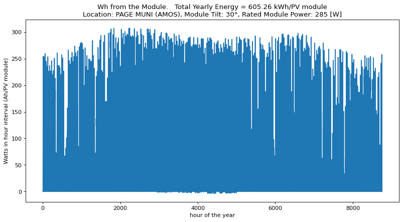

```python
plt.figure(figsize=(12, 6), dpi=80)
plt.title('Wh from the Module.   Total Yearly Energy = {:.2f} kWh/PV module'.format(P_yearly/1000) +
          f'\nLocation: {location_name}, Module Tilt: {module_elevation}°, Rated Module Power: 285 [W]')
plt.plot(df['total_module']*P_max/1000)
plt.xlabel('hour of the year')
plt.ylabel('Watts in hour interval (Ah/PV module)')
plt.show()
```

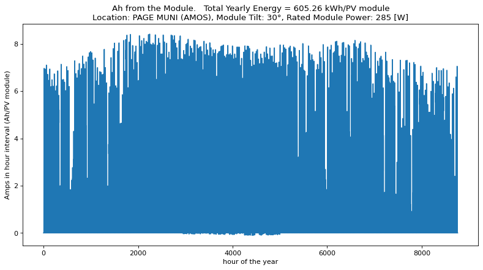

```python
plt.figure(figsize=(12, 6), dpi=80)
plt.title('Ah from the Module.   Total Yearly Energy = {:.2f} kWh/PV module'.format(P_yearly/1000) +
          f'\nLocation: {location_name}, Module Tilt: {module_elevation}°, Rated Module Power: 285 [W]')
plt.plot(df['PV_Array_Ah'])
plt.xlabel('hour of the year')
plt.ylabel('Amps in hour interval (Ah/PV module)')
plt.show()
```

1. Calculate and plot the load for every hour of the year, in the caption also giving the total kWh and Ah of the load in one year.  
   The load is calculated by finding the power of the load in each one hour period, and multiplying by the time it is “on” in that hour. E.g., a 20 W load running the full hour is 20Wh in that time period. A 1500 W toaster (not that the system has a toaster, but as an example), might be on 6 min in a one-hour period (e.g. it is on for 0.1 hour), so the load in that hour is (1500 W) (0.1h) = 150Wh.

```python
# Function to calculate the amount of light load for a given hour of the day based on that days sunset time
def light_load(sunset, hour):
    if np.floor(sunset) - 2 == hour:
        return 36*(1 - np.modf(sunset)[0])
    elif hour > np.floor(sunset) - 2 and hour < 22:
        return 36    # 36 Watts = 3*(4 Watt bulbs) + 1*(24 Watt Solitech Light)
    else:
        return 0
# Computing Sunrise and sunset times for all days in the year
df['sunrise'], df['sunset'] = pv.sun.sun_rise_set(latitude, pv.sun.declination(np.floor(df.index/24) + 1),
                pv.sun.time_correction(pv.sun.equation_of_time(np.floor(df.index/24) + 1), longitude, GMT_offset))

# using the light load function for each hour in the year.
df['light_load'] = df.apply(lambda row: light_load(row['sunset'], row['hour of day']), axis = 1)

# The inverter is 95% efficient and has 3 loads:  A chest Freezer, A screen, and a laptop
inverter_efficiency = 0.95

# The Chest Freezer is on 1 hour off 3 hours and is 95 W when on.
freezer = 95/inverter_efficiency    # The chest freezer consumes 95 W when running plus the efficiency factor
df['freezer_load'] = np.tile(np.array([freezer, 0, 0, 0]), 365*6)

# I will assume that the laptop and screen both run simultaneously and will be on from 9am to 12pm each day
screen = 20/inverter_efficiency
laptop = 30/inverter_efficiency
df['screen_load'] = np.tile(np.array([0, 0, 0, 0, 0, 0, 0, 0, screen, screen, screen, 0, 0, 0, 0, 0, 0,
                                      0, 0, 0, 0, 0, 0, 0]), 365)
df['laptop_load'] = np.tile(np.array([0, 0, 0, 0, 0, 0, 0, 0, laptop, laptop, laptop, 0, 0, 0, 0, 0, 0,
                                      0, 0, 0, 0, 0, 0, 0]), 365)

# Summing up power consumed for all load components at each hour of the year
df['total_load'] = df['laptop_load'] + df['screen_load'] + df['freezer_load'] + df['light_load']
# The total yearly load need in kWh
load_yearly = df['total_load'].sum()/1000
df['load_Ah'] = df['total_load']/system_voltage
load_Ah_yearly = df['load_Ah'].sum()/1000
```

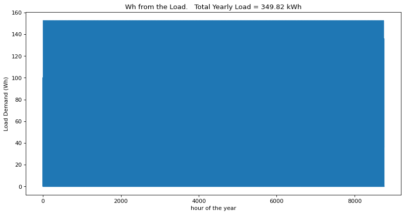

```python
plt.figure(figsize=(12, 6), dpi=80)
plt.title('Wh from the Load.   Total Yearly Load = {:.2f} kWh'.format(load_yearly))
plt.plot(df['total_load'])
plt.xlabel('hour of the year')
plt.ylabel('Load Demand (Wh)')
plt.show()
```

[figure not shown]

```python
plt.figure(figsize=(12, 6), dpi=80)
plt.title('Ah for the Load.   Total Yearly Load = {:.2f} kAh'.format(load_Ah_yearly))
plt.plot(df['load_Ah'])
plt.xlabel('hour of the year')
plt.ylabel('Load (Ah)')
plt.show()
```

1. Calculate the following parameters for every hour: PV Ah going to load; PV Ah “dumped”; - Battery state of charge; Load Ah from battery; Load Ah unavailable. There is a possible flow chart (there are lots of ways you can program it) in the programming notes section.  
   Plot the battery state of charge and one other of the above plots for every hour of the year.  
   Assume that the battery is fully charged at the beginning of the year.

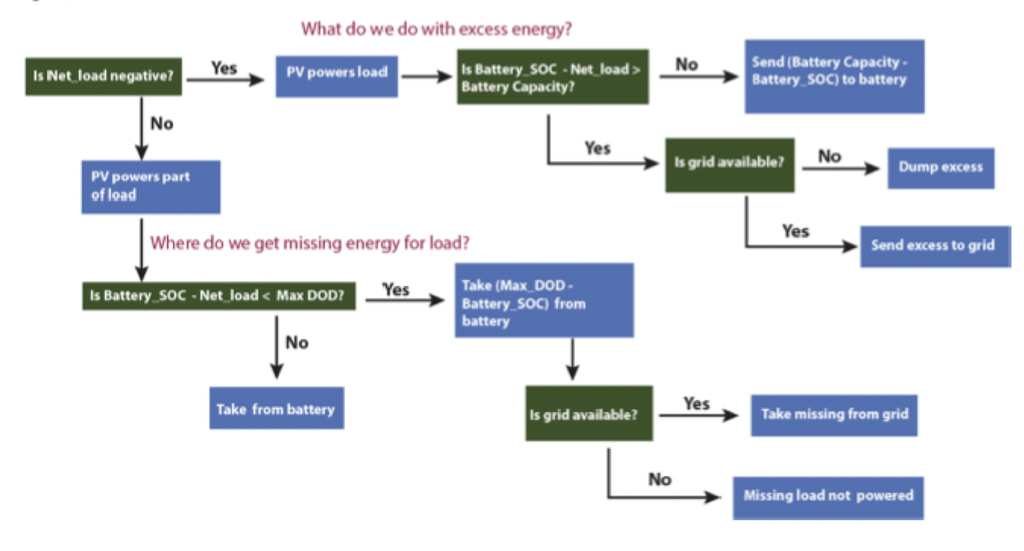

```python
Image(filename='EnergyFlowChart.png')
```

```python
# Difference between Ah demanded by the load vs PV_Ah generated.  Positive indicates that the load demands more than
# The pv modules can produce, so the backup battery is needed.
df['net_load'] = df['load_Ah'] - df['PV_Array_Ah']

# battery:
capacity = 72   # Battery Capcity in (Ah)
DOD = 0.2       # Depth of discharge - limit to how low we allow our battery to discharge to 20%

# Column to hold the battery state of charge percentage
df['BSOC'] = np.tile(np.array([0]), 24*365)   # will track the state of charge for the battery at the end of the hour
df['PV_to_load'] = np.tile(np.array([0]), 24*365)
df['PV_dumped'] = np.tile(np.array([0]), 24*365)
df['battery_to_load'] = np.tile(np.array([0]), 24*365)
df['load_unavailable'] = np.tile(np.array([0]), 24*365)
battery_0 = np.minimum(1.0, 1 - df['net_load'][0]/capacity)
df.loc[0, 'BSOC'] = battery_0
df.loc[0, 'battery_to_load'] = df['net_load'][0]

# BSOC Computations for each hour in the year:
for ind in range(1, len(df.index)):
    if df['net_load'][ind] <= 0:    # complete load supplied/ Surplus of PV generated Ah
        df.loc[ind, 'PV_to_load'] = df['load_Ah'][ind]

        battery = df['BSOC'][ind - 1] - df['net_load'][ind]/72
        if battery > 1:
            df.loc[ind, 'BSOC'] = 1
            df.loc[ind, 'PV_dumped'] = 72*(battery - 1)
        else:
            df.loc[ind, 'BSOC'] = battery
            df.loc[ind, 'PV_dumped'] = 0

        df.loc[ind, 'load_unavailable'] = 0
        df.loc[ind, 'battery_to_load'] = 0

    else:  # Not enough PV to supply the load
        df.loc[ind, 'PV_dumped'] = 0
        df.loc[ind, 'PV_to_load'] = df['PV_Array_Ah'][ind]   # All available PV goes to the load
        # Computation to see how the battery level will decrease in order to cover the rest of the load
        battery = df['BSOC'][ind - 1] - df['net_load'][ind]/72
        if battery >= DOD:   # if the battery level doesn't drop below its DOD
            df.loc[ind, 'battery_to_load'] = df['net_load'][ind]    # battery supplies the net load
            df.loc[ind, 'BSOC'] = battery  # battery level drops accordingly
        else:    # Battery reaches DOD limit
            # Send remaining battery power to the load
            df.loc[ind, 'battery_to_load'] = capacity * (df['BSOC'][ind - 1] - DOD)
            df.loc[ind, 'BSOC'] = DOD    # Drop battery level to DOD 20%
            df.loc[ind, 'load_unavailable'] = df['net_load'] - capacity * (df['BSOC'][ind - 1] - DOD)
average_BSOC = df['BSOC'].mean()
total_PV_dumped = df['PV_dumped'].sum()
df[['PV_Array_Ah', 'load_Ah', 'net_load', 'BSOC', 'PV_to_load', 'PV_dumped', 'battery_to_load',
    'load_unavailable']].head(24)
```

|  | PV_Array_Ah | load_Ah | net_load | BSOC | PV_to_load | PV_dumped | battery_to_load | load_unavailable |
| --- | --- | --- | --- | --- | --- | --- | --- | --- |
| 0 | 0.000000 | 2.083333 | 2.083333 | 0.971065 | 0.000000 | 0.000000 | 2.083333 | 0 |
| 1 | 0.000000 | 0.000000 | 0.000000 | 0.971065 | 0.000000 | 0.000000 | 0.000000 | 0 |
| 2 | 0.000000 | 0.000000 | 0.000000 | 0.971065 | 0.000000 | 0.000000 | 0.000000 | 0 |
| 3 | 0.000000 | 0.000000 | 0.000000 | 0.971065 | 0.000000 | 0.000000 | 0.000000 | 0 |
| 4 | 0.000000 | 2.083333 | 2.083333 | 0.942130 | 0.000000 | 0.000000 | 2.083333 | 0 |
| 5 | 0.000000 | 0.000000 | 0.000000 | 0.942130 | 0.000000 | 0.000000 | 0.000000 | 0 |
| 6 | 0.000000 | 0.000000 | 0.000000 | 0.942130 | 0.000000 | 0.000000 | 0.000000 | 0 |
| 7 | 0.000000 | 0.000000 | 0.000000 | 0.942130 | 0.000000 | 0.000000 | 0.000000 | 0 |
| 8 | 2.428641 | 3.179825 | 0.751184 | 0.931697 | 2.428641 | 0.000000 | 0.751184 | 0 |
| 9 | 4.565623 | 1.096491 | -3.469132 | 0.979879 | 1.096491 | 0.000000 | 0.000000 | 0 |
| 10 | 6.006369 | 1.096491 | -4.909878 | 1.000000 | 1.096491 | 3.461160 | 0.000000 | 0 |
| 11 | 6.017526 | 0.000000 | -6.017526 | 1.000000 | 0.000000 | 6.017526 | 0.000000 | 0 |
| 12 | 6.964069 | 2.083333 | -4.880736 | 1.000000 | 2.083333 | 4.880736 | 0.000000 | 0 |
| 13 | 6.568152 | 0.000000 | -6.568152 | 1.000000 | 0.000000 | 6.568152 | 0.000000 | 0 |
| 14 | 5.553393 | 0.562116 | -4.991276 | 1.000000 | 0.562116 | 4.991276 | 0.000000 | 0 |
| 15 | 3.942596 | 0.750000 | -3.192596 | 1.000000 | 0.750000 | 3.192596 | 0.000000 | 0 |
| 16 | 0.000000 | 2.833333 | 2.833333 | 0.960648 | 0.000000 | 0.000000 | 2.833333 | 0 |
| 17 | 0.000000 | 0.750000 | 0.750000 | 0.950231 | 0.000000 | 0.000000 | 0.750000 | 0 |
| 18 | 0.000000 | 0.750000 | 0.750000 | 0.939815 | 0.000000 | 0.000000 | 0.750000 | 0 |
| 19 | 0.000000 | 0.750000 | 0.750000 | 0.929398 | 0.000000 | 0.000000 | 0.750000 | 0 |
| 20 | 0.000000 | 2.833333 | 2.833333 | 0.890046 | 0.000000 | 0.000000 | 2.833333 | 0 |
| 21 | 0.000000 | 0.000000 | 0.000000 | 0.890046 | 0.000000 | 0.000000 | 0.000000 | 0 |
| 22 | 0.000000 | 0.000000 | 0.000000 | 0.890046 | 0.000000 | 0.000000 | 0.000000 | 0 |
| 23 | 0.000000 | 0.000000 | 0.000000 | 0.890046 | 0.000000 | 0.000000 | 0.000000 | 0 |

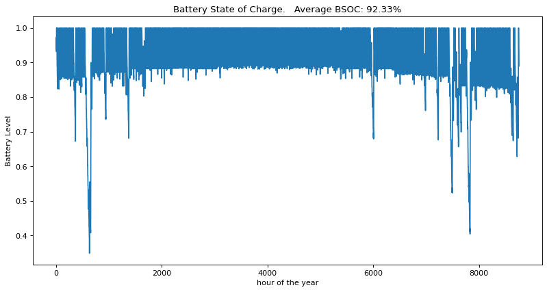

```python
plt.figure(figsize=(12, 6), dpi=80)
plt.title('Battery State of Charge.   Average BSOC: {:.2f}%'.format(100*average_BSOC))
plt.plot(df['BSOC'])
plt.xlabel('hour of the year')
plt.ylabel('Battery Level')
plt.show()
```

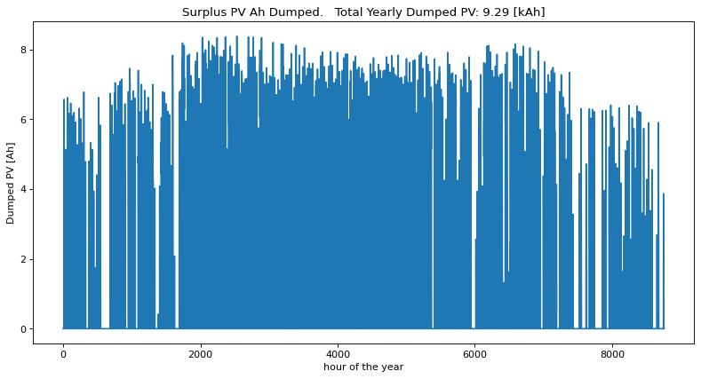

```python
plt.figure(figsize=(12, 6), dpi=80)
plt.title('Surplus PV Ah Dumped.   Total Yearly Dumped PV: {:.2f} [kAh]'.format(total_PV_dumped/1000))
plt.plot(df['PV_dumped'])
plt.xlabel('hour of the year')
plt.ylabel('Dumped PV [Ah]')
plt.show()
```

## Part 2: Analysis of PV System

1. Calculate and print out the availability of the system, where availability is defined as the ratio of the total powered load to the total requested load.

```python
system_availability = (df['PV_to_load'].sum() + df['battery_to_load'].sum())/df['load_Ah'].sum()
print('System Availability:', system_availability)
print('*The system never fails to supply the needed load.')
```

```
System Availability: 1.0
*The system never fails to supply the needed load.
```

1. Calculate and print out (1) the average battery state of charge of the system; (2) the lowest battery state of charge and the time of year when this occurs.

```python
print('Average Battery State of Charge (BSOC):', 100*average_BSOC, '%')
print('The lowest BSOC is', 100*df['BSOC'].min(), '%')
low = df[df['BSOC'] == df['BSOC'].min()]
low_date = str(low['Date (MM/DD/YYYY)'])[7:15]
print('This low occurs on the date:', low_date)
```

```
Average Battery State of Charge (BSOC): 92.33429926624879 %
The lowest BSOC is 34.89970351001196 %
This low occurs on the date: 01/27/19
```

1. Calculate and print out the ratio between the energy provided to the load and that generated by the PV system.

```python
ratio = (df['PV_to_load'].sum() + df['battery_to_load'].sum())/df['PV_Array_Ah'].sum()
print(round(100*ratio, 1), "% of the energy generated by the PV module is used to power the load, the other",
      round(100*(1 - ratio), 1), "% of generated energy is dumped.")
```

```
44.0 % of the energy generated by the PV module is used to power the load, the other 56.0 % of generated energy is dumped.
```